# Sentimental Analysis of ONEPLUS 6 Phone Reviews

————————- DATA EXTRACTION —————————

Libraries required for the extraction of reviews from amazon website are:  
1) ‘rvest’: For the web scraping  
2) ‘XML’: Used for pharsing the HTML data  
3) ‘magrittr’: Used for forward pipe operator

```r
library(magrittr) # for forward pipe operator
```

As libraries are loaded we should now assign the url

```r
######################## Amazon Reviews #############################
aurl <- "https://www.amazon.in/OnePlus-Mirror-Black-128GB-Storage/product-reviews/B0756VRJ25/ref=dpx_acr_txt?showViewpoints"
#Assigning NULL to a variable
amazon_reviews <- NULL
```

Reviews are extracted from every page by running the for loop

```r
###################### Extracting Reviews ##########################
for (i in 1:1800){
  murl <- read_html(as.character(paste(aurl,i,sep="=")))
  rev <- murl %>%
    html_nodes(".review-text") %>%
    html_text()
  amazon_reviews <- c(amazon_reviews,rev)
}
```

There are about 18,000 reviews approximately. Saving all these reviews locally in a text file

```r
write.table(amazon_reviews,"Amazon_oneplus6.txt")
```

————————- DATA CLEANING AND DATA MANIPULATION —————————

Data Cleaning is necessary to remove stopwords, white spaces, numbers, puntuations, html tags, convert the words into lower cases and other required transformations. Library reqiured is ‘tm’

```r
library(tm)
```

```r
#function for cleaning text data
stopwdrds = readLines(file.choose())
```

```
incomplete final line found on 'G:\EXCELR Data Science\Assignments\Text Analytics'\amazon\stop_words.txt'
```

Loading the text file

```r
length(x)
```

```
[1] 18001
```

The text file has 18,000 reviews in total  
The text file is coverted into corpus(collection of documents) for further cleaning

```r
# Preparing corpus from the text document
x <- text.clean(x)
x1 = Corpus(VectorSource(x))    # Constructs a source for a vector as input

x1 = tm_map(x1, stripWhitespace)    # removes white space
x1 = tm_map(x1, tolower)        # converts to lower case
x1 = tm_map(x1, removePunctuation)  # removes punctuation marks
x1 = tm_map(x1, removeNumbers)      # removes numbers in the documents
x1 = tm_map(x1, removeWords, c(stopwords("english"),stopwdrds,"macbook","apple","laptop","amazon"))
```

```r
#top 5 reviews
inspect(head(x1))
```

```
<<SimpleCorpus>>
Metadata:  corpus specific: 1, document level (indexed): 0
Content:  documents: 6

[1]
[2] bought phone month ago opinion  month  ios  oast years inly reason sticked ios son long  stability android   features advancement android ios  past couple years decided switch android  question hardware configuration  wanted  hardware configuration device eliminate slowness possibilities android…
[3]   start entire purchasing exoeroence  hype  decided invest  called popular product delivery delivery turned delivery courier asked  office saturday pick product packaging product box  bitten dogs tossed  multiple times handed dusty soiled outsidethe entire  bag soiled full dust remember item   p…
[4] usual customer knew job excellent manner exclusive sellers  india people glad inform delighted experience excellent exciting  bought tahnk  making  smile
[5]      gb model thought  switch brand   sway tide  mobile handset  giving good service gb ram gb storage parrallel competition market excellent product mobile handset market  dash charger works  charging battery full  minutes
[6]  foremost   prime delivery experience amazing ordered mobile oct   delivered    residing remote location thumbs  wide reach score high  competitor aspect  review product  technical man  putting simple layman  language device  se  uber cool gorgeous glossy finish face unlock feature pretty quick …
```

————————- SEMANTICS AND DATA VISUALISATION —————————

Required libraries to perform Text Analytics and VISUALISATIONS

```r
library(rJava)
library(SnowballC)
library(wordcloud)
library(qdap)
library(textir)
library(maptpx)
library(data.table)
library(stringr)
library(slam)
library(ggplot2)
```

Transforming the data to Term Document matrix

```r
# Term document frequency matrix
tdm0 <- TermDocumentMatrix(x1)
inspect(tdm0)
```

[output not shown]

```r
# Term document matrix with inverse frequency
tdm1 <- TermDocumentMatrix(x1,control = list(weighting = function(p) weightTfIdf(p,normalize = T)))#,stemming=T))
```

```
empty document(s): 1
```

```r
inspect(tdm1)
```

```
<<TermDocumentMatrix (terms: 693, documents: 18001)>>
Non-/sparse entries: 1158228/11316465
Sparsity           : 91%
Maximal term length: 15
Weighting          : term frequency - inverse document frequency (normalized) (tf-idf)
Sample             :
           Docs
Terms              118        128        138        168         18         28         38         68         78          8
  android   0.00000000 0.00000000 0.00000000 0.00000000 0.00000000 0.00000000 0.00000000 0.00000000 0.00000000 0.00000000
  avarage   0.00000000 0.00000000 0.00000000 0.00000000 0.00000000 0.00000000 0.00000000 0.00000000 0.00000000 0.00000000
  camera    0.00000000 0.00000000 0.00000000 0.00000000 0.00000000 0.00000000 0.00000000 0.00000000 0.00000000 0.00000000
  excellent 0.00000000 0.00000000 0.00000000 0.00000000 0.00000000 0.00000000 0.00000000 0.00000000 0.00000000 0.00000000
  hearing   0.00000000 0.00000000 0.00000000 0.00000000 0.00000000 0.00000000 0.00000000 0.00000000 0.00000000 0.00000000
  making    0.00000000 0.00000000 0.00000000 0.00000000 0.00000000 0.00000000 0.00000000 0.00000000 0.00000000 0.00000000
  mobile    0.00000000 0.00000000 0.00000000 0.00000000 0.00000000 0.00000000 0.00000000 0.00000000 0.00000000 0.00000000
  oneplus   0.05843574 0.05843574 0.05843574 0.05843574 0.05843574 0.05843574 0.05843574 0.05843574 0.05843574 0.05843574
  quality   0.00000000 0.00000000 0.00000000 0.00000000 0.00000000 0.00000000 0.00000000 0.00000000 0.00000000 0.00000000
  stream    0.00000000 0.00000000 0.00000000 0.00000000 0.00000000 0.00000000 0.00000000 0.00000000 0.00000000 0.00000000
```

Now let’s check whether the both documents that does not contain the terms or words and remove them. The indexes of the document is obtained.

```r
a0 <- NULL
a1 <- NULL
# getting the indexes of documents having count of words = 0
for (i1 in 1:ncol(tdm0))
{ if (sum(tdm0[, i1]) == 0) {a0 = c(a0, i1)} }
for (i1 in 1:ncol(tdm1))
{ if (sum(tdm1[, i1]) == 0) {a1 = c(a1, i1)} }
length(a0)
```

```
[1] 1
```

```r
a0
```

```
[1] 1
```

```r
length(a1)
```

```
[1] 1
```

```r
a1
```

```
[1] 1
```

In both the TDMs there is one document without any terms i.e, the first document, so lets remove them.

```r
# Removing empty docs
if(length(a0)!=0){
  tdm0 <- tdm0[,-a0]

}
if (length(a1)!=0){
  tdm1 <- tdm1[,-a1]
}
inspect(tdm0)
```

```
<<TermDocumentMatrix (terms: 693, documents: 18000)>>
Non-/sparse entries: 1158228/11315772
Sparsity           : 91%
Maximal term length: 15
Weighting          : term frequency (tf)
Sample             :
            Docs
Terms        119 129 139 169 19 29 39 69 79 9
  android      2   2   2   2  2  2  2  2  2 2
  battery      4   4   4   4  4  4  4  4  4 4
  camera       1   1   1   1  1  1  1  1  1 1
  delivery     0   0   0   0  0  0  0  0  0 0
  device       4   4   4   4  4  4  4  4  4 4
  display      2   2   2   2  2  2  2  2  2 2
  experience   1   1   1   1  1  1  1  1  1 1
  good         5   5   5   5  5  5  5  5  5 5
  oneplus      1   1   1   1  1  1  1  1  1 1
  phone        7   7   7   7  7  7  7  7  7 7
```

```r
inspect(tdm1)
```

```
<<TermDocumentMatrix (terms: 693, documents: 18000)>>
Non-/sparse entries: 1158228/11315772
Sparsity           : 91%
Maximal term length: 15
Weighting          : term frequency - inverse document frequency (normalized) (tf-idf)
Sample             :
           Docs
Terms              118        128        138        168         18         28         38         68         78          8
  android   0.00000000 0.00000000 0.00000000 0.00000000 0.00000000 0.00000000 0.00000000 0.00000000 0.00000000 0.00000000
  avarage   0.00000000 0.00000000 0.00000000 0.00000000 0.00000000 0.00000000 0.00000000 0.00000000 0.00000000 0.00000000
  camera    0.00000000 0.00000000 0.00000000 0.00000000 0.00000000 0.00000000 0.00000000 0.00000000 0.00000000 0.00000000
  excellent 0.00000000 0.00000000 0.00000000 0.00000000 0.00000000 0.00000000 0.00000000 0.00000000 0.00000000 0.00000000
  hearing   0.00000000 0.00000000 0.00000000 0.00000000 0.00000000 0.00000000 0.00000000 0.00000000 0.00000000 0.00000000
  making    0.00000000 0.00000000 0.00000000 0.00000000 0.00000000 0.00000000 0.00000000 0.00000000 0.00000000 0.00000000
  mobile    0.00000000 0.00000000 0.00000000 0.00000000 0.00000000 0.00000000 0.00000000 0.00000000 0.00000000 0.00000000
  oneplus   0.05843574 0.05843574 0.05843574 0.05843574 0.05843574 0.05843574 0.05843574 0.05843574 0.05843574 0.05843574
  quality   0.00000000 0.00000000 0.00000000 0.00000000 0.00000000 0.00000000 0.00000000 0.00000000 0.00000000 0.00000000
  stream    0.00000000 0.00000000 0.00000000 0.00000000 0.00000000 0.00000000 0.00000000 0.00000000 0.00000000 0.00000000
```

To visualise the data we need to build word cloud. Word clouds can be of two types: positive and negative. Functions need to be build for these clouds. To differentiate between positive and negative words we need to call the data of positive words and negative words.

```r
# lOADING +VE AND -VE words
pos.words=readLines(file.choose())  # read-in positive-words.txt
neg.words=readLines(file.choose())  # read-in negative-words.txt
pos.words=c(pos.words,"wow", "kudos", "hurray")             # including our own positive words to the existing list
neg.words = c(neg.words)
```

For wordcloud function is

```r
#function for the wordcloud
makewordc = function(x){
  freq = sort(rowSums(as.matrix(x)),decreasing = TRUE)
  freq.df = data.frame(word=names(freq), freq=freq)
  wordcloud(freq.df$word[1:85], freq.df$freq[1:85],scale = c(4,.5),random.order = F, colors=1:10)
}
```

For positive wordcloud

```r
# Making positive wordcloud function
makeposwordc = function(x){
  freq = sort(rowSums(as.matrix(x)),decreasing = TRUE)
  # matching positive words
  pos.matches = match(names(freq), c(pos.words,"approvals"))
  pos.matches = !is.na(pos.matches)
  freq_pos <- freq[pos.matches]
  names <- names(freq_pos)
  wordcloud(names,freq_pos,scale=c(4,.5),colors = brewer.pal(8,"Dark2"))
}
```

For negative wordcloud

```r
# Making negatice wordcloud function
makenegwordc = function(x){
  freq = sort(rowSums(as.matrix(x)),decreasing = TRUE)
  # matching positive words
  neg.matches = match(names(freq), neg.words)
  neg.matches = !is.na(neg.matches)
  freq_neg <- freq[neg.matches]
  names <- names(freq_neg)
  #wordcloud(names[1:120],freq_neg[1:120],scale=c(4,.5),colors = brewer.pal(8,"Dark2"))
  wordcloud(names,freq_neg,scale=c(4,.5),colors = brewer.pal(8,"Dark2"))
}
```

The most frequently used words can found by barplots. For barplot the funcyion is:

```r
#Barplot for the most number of words used
words_bar_plot <- function(x){
  freq = sort(rowSums(as.matrix(x)),decreasing = TRUE)
  freq.df = data.frame(word=names(freq), freq=freq)
  head(freq.df, 10)
  library(ggplot2)
  ggplot(head(freq.df,30), aes(reorder(word,freq), freq)) +
    geom_bar(stat = "identity") + coord_flip() +
    xlab("Words") + ylab("Frequency") +
    ggtitle("Most frequent words")

}
```

For positive barplot

```r
#barplot for positve words
pos_words_bar_plot <- function(x){
  pos.matches = match(colnames(x), pos.words)
  pos.matches = !is.na(pos.matches)
  pos_words_freq = as.data.frame(apply(x, 2, sum)[pos.matches])
  colnames(pos_words_freq)<-"freq"
  pos_words_freq["word"] <- rownames(pos_words_freq)
  # Sorting the words in deceasing order of their frequency
  pos_words_freq <- pos_words_freq[order(pos_words_freq$freq,decreasing=T),]
  ggplot(head(pos_words_freq,30), aes(reorder(word,freq), freq)) +
    geom_bar(stat = "identity") + coord_flip() +
    xlab("Positive words") + ylab("Frequency") +
    ggtitle("Most frequent positive words")
}
```

for negative barplot

```r
#barplot for the negative words
neg_words_bar_plot <- function(x){
  neg.matches = match(colnames(x), neg.words)
  neg.matches = !is.na(neg.matches)
  neg_words_freq = as.data.frame(apply(x, 2, sum)[neg.matches])
  colnames(neg_words_freq)<-"freq"
  neg_words_freq["word"] <- rownames(neg_words_freq)
  # Sorting the words in deceasing order of their frequency
  neg_words_freq <- neg_words_freq[order(neg_words_freq$freq,decreasing=T),]
  ggplot(head(neg_words_freq,30), aes(reorder(word,freq), freq)) +
    geom_bar(stat = "identity") + coord_flip() +
    xlab("words") + ylab("Frequency") +
    ggtitle("Most frequent negative words")
}
```

cluster diagram helps us to understand the words closer to each other

```r
clusdend = function(a){ # writing func clusdend()

  a <- inspect(a)
  mydata.df = as.data.frame(t(as.matrix(a)));
  dist_df <- dist(mydata.df,method="euclidean")
  plot(hclust(dist_df,method="single"),hang=-1)
}
```

Transpose the matrix for visualisation

```r
# Document term matrix
dtm0 <- t(tdm0)
dtm1 <- t(tdm1)
```

Word cloud for frequent words

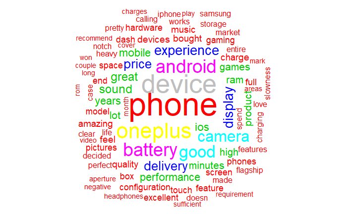

```r
makewordc(tdm0)
```

frequent words barplot

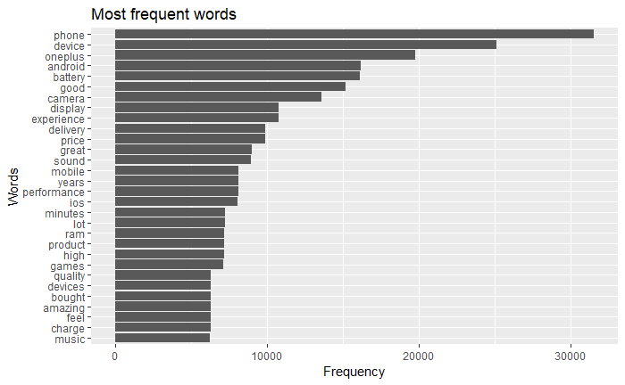

```r
words_bar_plot(tdm0)
```

word cloud for positive words

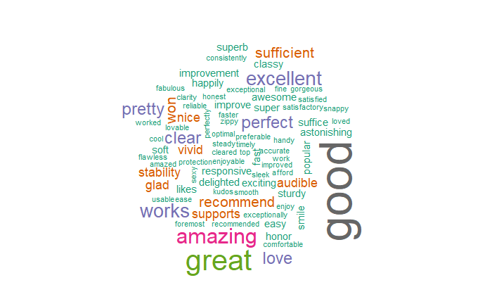

```r
makeposwordc(tdm0)
```

frequent positve words barplot

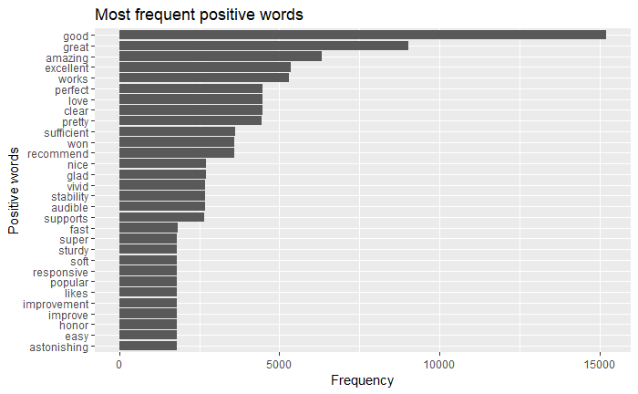

```r
pos_words_bar_plot(dtm0)
```

Negative wordcloud

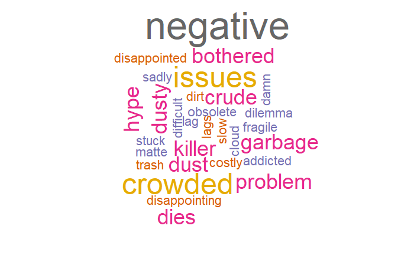

```r
makenegwordc(tdm0)
```

frequent negative words

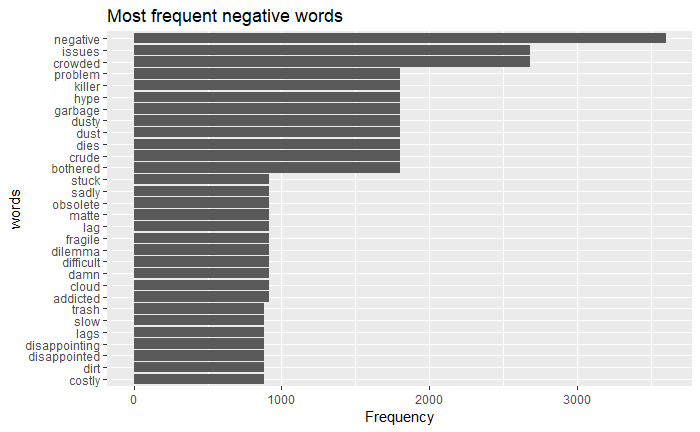

```r
neg_words_bar_plot(dtm0)
```

###### ——–For normalised data ——–

word cloud for normalised data

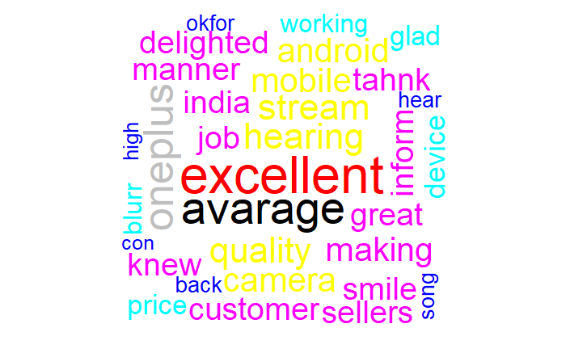

```r
makewordc(tdm1)
```

barplot for normalised data

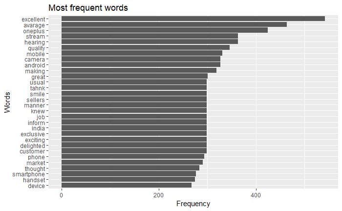

```r
words_bar_plot(tdm1)
```

Positive Word Cloud

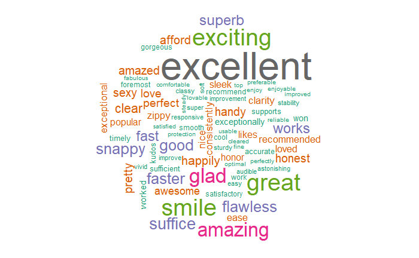

```r
makeposwordc(tdm1)
```

Frequent positive Barplot

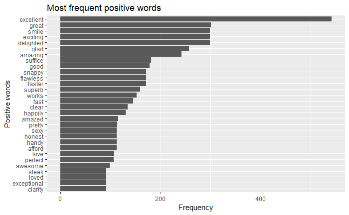

```r
pos_words_bar_plot(dtm1)
```

Negative word cloud

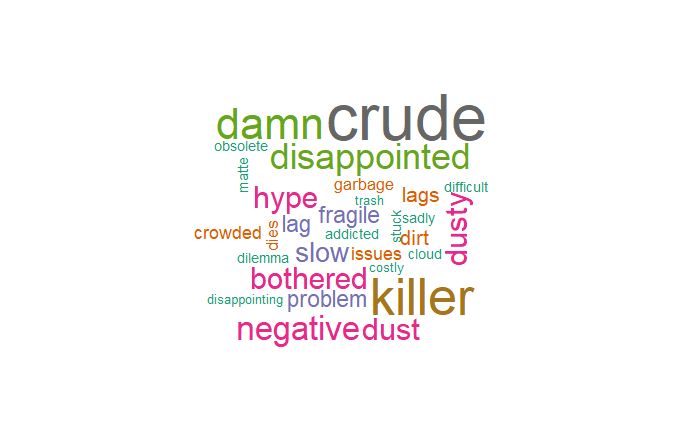

```r
makenegwordc(tdm1)
```

Frequent negative words barplots

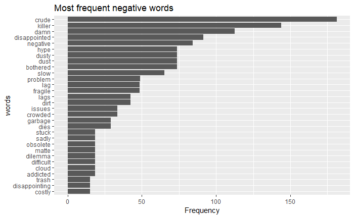

```r
neg_words_bar_plot(dtm1)
```

Cluster diagram for dtm0

```r
# Cluster dendrogram on Uni gram - TF
clusdend(dtm0)
```

```
<<DocumentTermMatrix (documents: 18000, terms: 693)>>
Non-/sparse entries: 1158228/11315772
Sparsity           : 91%
Maximal term length: 15
Weighting          : term frequency (tf)
Sample             :
     Terms
Docs  android battery camera delivery device display experience good oneplus phone
  119       2       4      1        0      4       2          1    5       1     7
  129       2       4      1        0      4       2          1    5       1     7
  139       2       4      1        0      4       2          1    5       1     7
  169       2       4      1        0      4       2          1    5       1     7
  19        2       4      1        0      4       2          1    5       1     7
  29        2       4      1        0      4       2          1    5       1     7
  39        2       4      1        0      4       2          1    5       1     7
  69        2       4      1        0      4       2          1    5       1     7
  79        2       4      1        0      4       2          1    5       1     7
  9         2       4      1        0      4       2          1    5       1     7
```

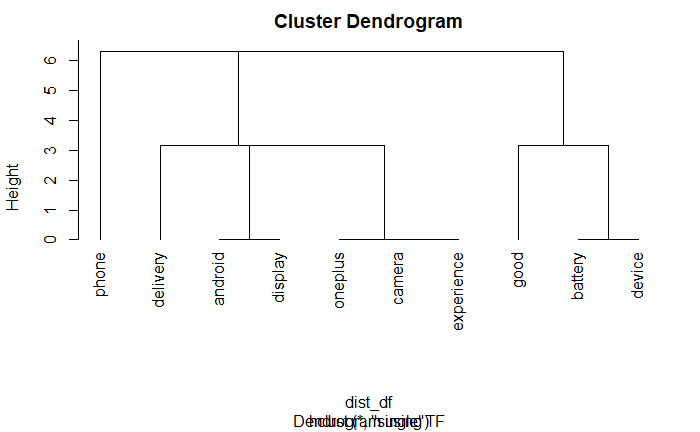

```r
title(sub = "Dendrogram using TF")
```

The above cluster diagram shows the words close to each other

————————– EMOTION MINING ————————–

```r
library("syuzhet")
```

```r
s_v <- get_sentences(x)
class(s_v)
```

```
[1] "character"
```

```r
str(s_v)
```

```
 chr [1:18001] "" ...
```

```r
head(s_v)
```

```
[1] ""
[2] "bought phone month ago opinion using month using ios since oast years inly reason sticked ios son long s stability android however seeing features advancement android ios since past couple years decided switch android just question hardware configuration hence wanted best hardware configuration…
[3] "let s start entire purchasing exoeroence much hype around decided invest k called popular product delivery delivery turned delivery courier asked come office saturday pick product packaging product box seemed bitten dogs tossed around multiple times handed dusty soiled outsidethe entire outside…
[4] "usual customer knew job excellent manner exclusive sellers plus india people glad inform delighted experience excellent exciting ever bought tahnk amazon making us smile"
[5] "actually using second apple s gb model thought better switch brand plus able sway tide apple mobile handset definitely giving good service gb ram gb storage parrallel competition market excellent product mobile handset market s dash charger works well charging battery full just minutes"
[6] "first foremost amazon s prime delivery experience amazing ordered mobile oct th got delivered next around despite residing remote location thumbs amazon wide reach score high immediate competitor aspect brief review product m technical man just putting simple layman s language device per se loo…
```

The get_sentiment function helps us to measure the emotions, below zero represents the negativity,zero is neutral and above zero represents positivity in sentences. There are different methods to extract emotion in each sentences

```r
sentiment_vector <- get_sentiment(s_v, method = "bing")
head(sentiment_vector)
```

```
[1]  0 19 -2  5  5  9
```

```r
afinn_s_v <- get_sentiment(s_v, method = "afinn")
head(afinn_s_v)
```

```
[1]  0 32  3 16  8 11
```

```r
nrc_vector <- get_sentiment(s_v, method="nrc")
head(nrc_vector)
```

```
[1]  0 12  3  8  3  8
```

lets consider bing method and plot line graph for first 200 reviews

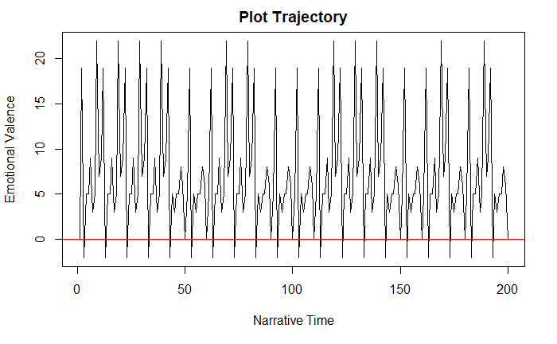

```r
plot(sentiment_vector[1:200], type = "l", main = "Plot Trajectory",
     xlab = "Narrative Time", ylab = "Emotional Valence")
abline(h = 0, col = "red")
```

To extract the sentence with the most negative emotional valence

```r
negative <- s_v[which.min(sentiment_vector)]
negative
```

```
[1] "let s start entire purchasing exoeroence much hype around decided invest k called popular product delivery delivery turned delivery courier asked come office saturday pick product packaging product box seemed bitten dogs tossed around multiple times handed dusty soiled outsidethe entire outside…
```

To extract the most positive sentence

```r
positive <- s_v[which.max(sentiment_vector)]
positive
```

```
[1] "bought flagship smartphone oneplus months back observations using months camera just fabulous works like dslr inbuilt features available dslr supports features like focus aperture iso etc set features custom per requirement sound microphone quality just awesome audible even crowded places earpi…
```

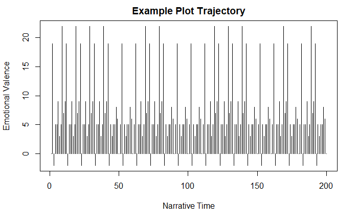

```r
# more depth
poa_v <- x
poa_sent <- get_sentiment(poa_v[1:200], method="bing")
plot(
  poa_sent,
  type="h",
  main="Example Plot Trajectory",
  xlab = "Narrative Time",
  ylab= "Emotional Valence"
)
```

percentage based figures

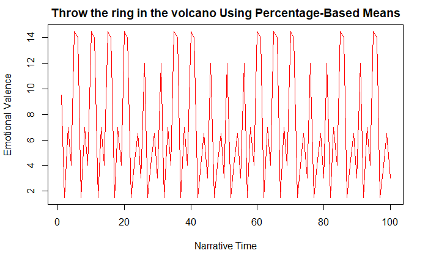

```r
percent_vals <- get_percentage_values(poa_sent)
plot(
  percent_vals,
  type="l",
  main="Throw the ring in the volcano Using Percentage-Based Means",
  xlab = "Narrative Time",
  ylab= "Emotional Valence",
  col="red"
)
```

categorize each sentence by eight emotions

```r
nrc_data <- get_nrc_sentiment(s_v)
```

```r
sad_items <- which(nrc_data$sadness > 0)
head(s_v[sad_items])
```

```
[1] "bought phone month ago opinion using month using ios since oast years inly reason sticked ios son long s stability android however seeing features advancement android ios since past couple years decided switch android just question hardware configuration hence wanted best hardware configuration…
[2] "let s start entire purchasing exoeroence much hype around decided invest k called popular product delivery delivery turned delivery courier asked come office saturday pick product packaging product box seemed bitten dogs tossed around multiple times handed dusty soiled outsidethe entire outside…
[3] "first foremost amazon s prime delivery experience amazing ordered mobile oct th got delivered next around despite residing remote location thumbs amazon wide reach score high immediate competitor aspect brief review product m technical man just putting simple layman s language device per se loo…
[4] "wanting purchase oneplus phone diviated oneplus notch came wasn t big fan waited t realised notch still jack removed happily took oneplus s pretty much exceptionally good phone display mostly mesmerised duality photo video pretty much per expectations d love control slow motion timelapse though…
[5] "bought flagship smartphone oneplus months back observations using months camera just fabulous works like dslr inbuilt features available dslr supports features like focus aperture iso etc set features custom per requirement sound microphone quality just awesome audible even crowded places earpi…
[6] "used oneplus years oneplus never disappointed even purchase oneplus amazing simply superb opted oneplus t didnt find much changes t n pay another huge amount exchanged oneplus n putting additional sbi offer great indian sale got phone sound clarity perfect call n music toocamera exceptional lov…
```

```r
trust_items <- which(nrc_data$trust > 0)
head(s_v[trust_items])
```

```
[1] "bought phone month ago opinion using month using ios since oast years inly reason sticked ios son long s stability android however seeing features advancement android ios since past couple years decided switch android just question hardware configuration hence wanted best hardware configuration…
[2] "let s start entire purchasing exoeroence much hype around decided invest k called popular product delivery delivery turned delivery courier asked come office saturday pick product packaging product box seemed bitten dogs tossed around multiple times handed dusty soiled outsidethe entire outside…
[3] "usual customer knew job excellent manner exclusive sellers plus india people glad inform delighted experience excellent exciting ever bought tahnk amazon making us smile"
[4] "actually using second apple s gb model thought better switch brand plus able sway tide apple mobile handset definitely giving good service gb ram gb storage parrallel competition market excellent product mobile handset market s dash charger works well charging battery full just minutes"
[5] "first foremost amazon s prime delivery experience amazing ordered mobile oct th got delivered next around despite residing remote location thumbs amazon wide reach score high immediate competitor aspect brief review product m technical man just putting simple layman s language device per se loo…
[6] "picture quality hd stream good regular stream okfor sound increase volume hear clear sound especially hearing song dialogue hearing newsweight also averagebattery life okbuttons given crude suffice bodytaking consideration points price charge much higher comare phones available market specifica…
```

```r
fear_items <- which(nrc_data$fear > 0)
head(s_v[fear_items])
```

```
[1] "bought phone month ago opinion using month using ios since oast years inly reason sticked ios son long s stability android however seeing features advancement android ios since past couple years decided switch android just question hardware configuration hence wanted best hardware configuration…
[2] "picture quality hd stream good regular stream okfor sound increase volume hear clear sound especially hearing song dialogue hearing newsweight also averagebattery life okbuttons given crude suffice bodytaking consideration points price charge much higher comare phones available market specifica…
[3] "bought flagship smartphone oneplus months back observations using months camera just fabulous works like dslr inbuilt features available dslr supports features like focus aperture iso etc set features custom per requirement sound microphone quality just awesome audible even crowded places earpi…
[4] "bought phone month ago opinion using month using ios since oast years inly reason sticked ios son long s stability android however seeing features advancement android ios since past couple years decided switch android just question hardware configuration hence wanted best hardware configuration…
[5] "picture quality hd stream good regular stream okfor sound increase volume hear clear sound especially hearing song dialogue hearing newsweight also averagebattery life okbuttons given crude suffice bodytaking consideration points price charge much higher comare phones available market specifica…
[6] "bought flagship smartphone oneplus months back observations using months camera just fabulous works like dslr inbuilt features available dslr supports features like focus aperture iso etc set features custom per requirement sound microphone quality just awesome audible even crowded places earpi…
```

```r
disgust_items <- which(nrc_data$disgust > 0)
head(s_v[disgust_items])
```

```
[1] "bought phone month ago opinion using month using ios since oast years inly reason sticked ios son long s stability android however seeing features advancement android ios since past couple years decided switch android just question hardware configuration hence wanted best hardware configuration…
[2] "let s start entire purchasing exoeroence much hype around decided invest k called popular product delivery delivery turned delivery courier asked come office saturday pick product packaging product box seemed bitten dogs tossed around multiple times handed dusty soiled outsidethe entire outside…
[3] "first foremost amazon s prime delivery experience amazing ordered mobile oct th got delivered next around despite residing remote location thumbs amazon wide reach score high immediate competitor aspect brief review product m technical man just putting simple layman s language device per se loo…
[4] "picture quality hd stream good regular stream okfor sound increase volume hear clear sound especially hearing song dialogue hearing newsweight also averagebattery life okbuttons given crude suffice bodytaking consideration points price charge much higher comare phones available market specifica…
[5] "wanting purchase oneplus phone diviated oneplus notch came wasn t big fan waited t realised notch still jack removed happily took oneplus s pretty much exceptionally good phone display mostly mesmerised duality photo video pretty much per expectations d love control slow motion timelapse though…
[6] "bought flagship smartphone oneplus months back observations using months camera just fabulous works like dslr inbuilt features available dslr supports features like focus aperture iso etc set features custom per requirement sound microphone quality just awesome audible even crowded places earpi…
```

To view the emotions as a barplot

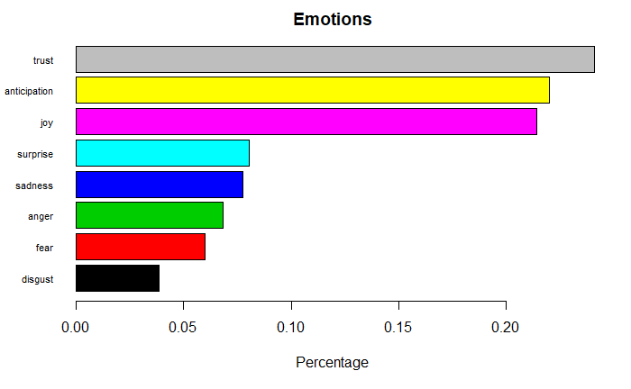

```r
barplot(sort(colSums(prop.table(nrc_data[, 1:8]))), horiz = T, cex.names = 0.7,
        las = 1, main = "Emotions", xlab = "Percentage",
        col = 1:8)
```

From the above plot we can say that the phone has positivness in customers.